# Portfolio 9: Where does the time go?

Author

John Lavack 20001249

Published

29 Sep 2026

Use the `economics` dataset from `ggplot2` package (we also explored this in the lab) produced from US economic time series data available from https://fred.stlouisfed.org/.

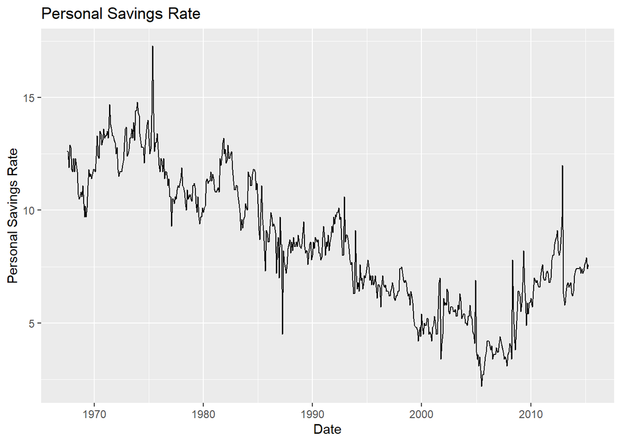

## Make variables

```r
chart_data <- economics %>%
  mutate(
    year = as.integer(year(date))) %>%
  group_by(year) %>%
  summarise(
    median_saving_rate = median(psavert),
    median_unemployment_rate = median(uempmed),
    .groups = 'drop'
  ) %>%
  mutate(
    change_median_saving_rate = median_saving_rate - lag(median_saving_rate),
    change_median_unemployment_rate = median_unemployment_rate - lag(median_unemployment_rate)
  ) %>%
  na.omit() #drop first year as it has no lag.
```

## Your Figure

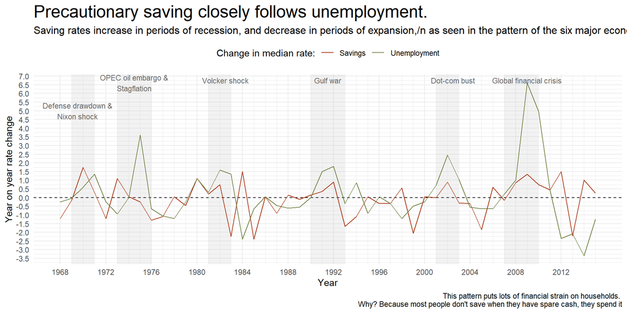

```r
# make an appropriate figure
chart_data %>%
  ggplot(aes(x = year)) +
  #shaded recessions
  annotate("rect", xmin = 1969, xmax = 1971, ymin = -Inf, ymax = Inf,
           fill = "grey", alpha = 0.2) +
  annotate("rect", xmin = 1973, xmax = 1976, ymin = -Inf, ymax = Inf,
           fill = "grey", alpha = 0.2) +
  annotate("rect", xmin = 1981, xmax = 1983, ymin = -Inf, ymax = Inf,
           fill = "grey", alpha = 0.2) +
  annotate("rect", xmin = 1990, xmax = 1993, ymin = -Inf, ymax = Inf,
           fill = "grey", alpha = 0.2) +
  annotate("rect", xmin = 2001, xmax = 2003, ymin = -Inf, ymax = Inf,
           fill = "grey", alpha = 0.2) +
  annotate("rect", xmin = 2007, xmax = 2010, ymin = -Inf, ymax = Inf,
           fill = "grey", alpha = 0.2) +
  geom_hline(aes(yintercept = 0), col = "#18171e", linetype = "dashed") +
  #text annotation
  annotate("text", x = 1969.5, y = 5, label = "Defense drawdown &\nNixon shock",
           size = 3, colour = "grey40") +
  annotate("text", x = 1974.5, y = Inf, label = "OPEC oil embargo &\nStagflation",
           vjust = 1, size = 3, colour = "grey40") +
  annotate("text", x = 1982.5, y = Inf, label = "Volcker shock",
           vjust = 1.5, size = 3, colour = "grey40") +
  annotate("text", x = 1991.5, y = Inf, label = "Gulf war",
           vjust = 1.5, size = 3, colour = "grey40") +
  annotate("text", x = 2002.5, y = Inf, label = "Dot-com bust",
           vjust = 1.5, size = 3, colour = "grey40") +
  annotate("text", x = 2009, y = Inf, label = "Global financial crisis",
           vjust = 1.5, size = 3, colour = "grey40") +
  #and the rest
  # geom_vline(xintercept = c(1975, 1982, 1992, 2002, 2009), col = "#18171e", linetype = "dashed") +
  geom_line(aes(y = change_median_saving_rate, col = "Savings")) +
  geom_line(aes(y = change_median_unemployment_rate, col = "Unemployment")) +
  #annotations

  #scale arguments
  scale_color_manual(values = c(
    "Savings" = "#a93413",
    "Unemployment" = "#718346"
    ),
    name = "Change in median rate:"
  ) +
  scale_x_continuous(
    breaks = seq(min(chart_data$year), max(chart_data$year), by = 4),
    minor_breaks = seq(min(chart_data$year), max(chart_data$year), by = 1)
  ) +
  scale_y_continuous(
    breaks = scales::breaks_width(0.5),
    minor_breaks = scales::breaks_width(0.25)
  ) +
  #labels
  labs(title = "Precautionary saving closely follows unemployment.",
       subtitle = "Saving rates increase in periods of recession, and decrease in periods of expansion,/n as seen in the pattern of the six major economic shocks from 1967 to 2015",
       caption = "This pattern puts lots of financial strain on households. \nWhy? Because most people don't save when they have spare cash, they spend it",
       y = "Year on year rate change",
       x = "Year") +
  #theme
  theme_minimal() +
  theme(
    legend.position = "top",
    plot.title = element_text(size = 20),
    plot.subtitle = element_text(size = 12),
   )
```

## Explanation

Overall, saving rates are trending downwards, with what looks like a reversal following the global financial crisis (GFC) of 2008. The chart above shows that unemployment and saving rates move pretty similarly through time. Events shock the economy, like the post Vietnam war defence draw down, the Nixon shock, the OPEC oil embargo, the Gulf war and the GFC. These shocks cause the economy to contract. Most businesses do not operate with sufficient margins to sustain all their employees is period of economic contraction, so people lose their jobs. Unemployment increases. Saving increase at the worst time to start saving - when the recession hits. Eventually the economy recovers. Businesses can hire again and savings decrease as people spend more.  
This demonstrates the income elasticity of consumption and the supply and demand of labour. It is conventional wisdom to ‘make hay while the sun is shining’. However, this is seldom practised, because, as if often said, ‘money burns a hole through your pockets’. People make decisions to solve proximal problems. Problems that are both near and urgent. We aren’t very good at thinking ahead towards future financial security.